# Final project

Author

Mansi Patel, mdp86

Published

2025-12-05

```r
#install.packages("ggvenn")
library(ggvenn)
library(readxl)
library(purrr)
library(tidyverse)
library(stringr)
library(patchwork)
library(ggrepel)

#install.packages("devtools")
#devtools::install_github("jolars/eulerr")

library(eulerr)
library(RColorBrewer)
library(ggplot2)
```

```r
#ger the names of the sheets in the file
sheet_names <- excel_sheets("pnas.2322588121.sd02.xlsx")

#loop through all the data sheets and get them individually
sheets <- map(sheet_names, ~read_excel("pnas.2322588121.sd02.xlsx", sheet = .x))
names(sheets) <- sheet_names
```

```r
#get individual data frames
fig_A_data <- sheets[[1]]
names(fig_A_data) <- c("all_sample_UniProt_accession", "all_sample_gene_name", "one_sample_UniProt_accession", "one_sample_gene_name")
fig_A_data <- fig_A_data[-c(1,2,3), ]
fig_A_data <- fig_A_data |>
  select(all_sample_gene_name, one_sample_gene_name)



fig_B_data <- sheets[[2]]
names(fig_B_data) <- c("all_sample_UniProt_accession", "all_sample_gene_name", "one_sample_UniProt_accession", "one_sample_gene_name")
fig_B_data <- fig_B_data[-c(1,2,3), ]
fig_B_data <- fig_B_data |>
  select(all_sample_gene_name, one_sample_gene_name)


fig_CD_data <- sheets[[3]]
fig_CD_data_col_names <- fig_CD_data[2,]
fig_CD_data_col_names <-unname(unlist(fig_CD_data_col_names))
names(fig_CD_data) <- fig_CD_data_col_names
fig_CD_data <- fig_CD_data[-c(1, 2), ]



fig_E_data <- sheets[[4]]
fig_E_data <- fig_E_data[-c(1,2), ]
fig_E_data_gonad <- fig_E_data[ , c(1:12)]
second_header <- fig_E_data_gonad[1,]
second_header_col_names <- unname(unlist(second_header))
second_header_two <- second_header[,c(1,3,5,7,9,11)]
names(fig_E_data_gonad) <- second_header_col_names
names(fig_E_data_gonad)[c(2,4,6,8,10,12)] <- second_header_two
fig_E_data_gonad <- fig_E_data_gonad[-c(1,2), ]
fig_E_data_gonad <- fig_E_data_gonad[,c(2,4,6,8,10,12)]


fig_E_data_intestine <- fig_E_data[ , c(14:25)]
second_header_intestine <- fig_E_data_intestine[1,]
second_header_col_names <- unname(unlist(second_header_intestine))
second_header_two <- second_header_intestine[,c(1,3,5,7,9,11)]
names(fig_E_data_intestine) <- second_header_col_names
names(fig_E_data_intestine)[c(2,4,6,8,10,12)] <- second_header_two
fig_E_data_intestine <- fig_E_data_intestine[-c(1,2), ]
fig_E_data_intestine <- fig_E_data_intestine[,c(2,4,6,8,10,12)]


fig_FG_data <- sheets[[5]]
fig_FG_data <- fig_FG_data[-1,]
second_header_FG <- fig_FG_data[1,]
second_header_FG_first_half <- second_header_FG[,c(1,3,5)]
names(fig_FG_data)[c(2,4,6)] <- second_header_FG_first_half
second_header_FG_second_half <- fig_FG_data[2,][,c(7:16)]
names(fig_FG_data)[c(7:16)] <- second_header_FG_second_half
```

# Fig A

```r
all_sample_gene_name <- unique(fig_A_data$all_sample_gene_name)
length_all_sample_gene_name <- length(all_sample_gene_name)

one_sample_gene_name <- unique(fig_A_data$one_sample_gene_name)

legnth_of_the_matches <- length(intersect(all_sample_gene_name, one_sample_gene_name))
```

radius of the bigger circle is 1, the area of this circle represents 100% genes. the area of the smaller circle represents 82.7% of that. area of circle is pi r^2. based on that the radius of the smaller circle should be

radius_of_small_circle^2/1 = 0.827

radius_of_small_circle = 0.9093954

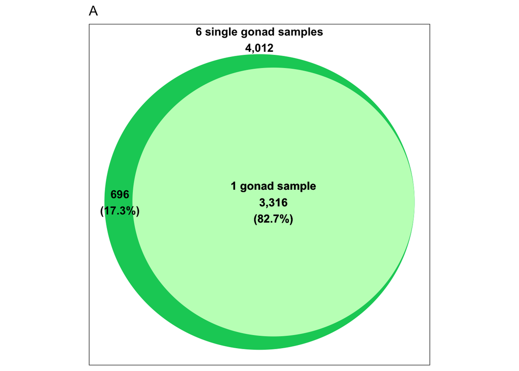

```r
# radius calculation for the smaller circle
data <- data.frame(x = c(0,0.09),
                   y = c(0,0),
                   r = c(1, 0.9093954),
                   fill = c("#00CD66", "#C1FFC1"),
                   label = c("6 single gonad samples\n4,012", "1 gonad sample\n3,316\n(82.7%)"))

library(ggforce)
fig_A <-
  ggplot(data, aes(x0 = x, y0 = y, r = r)) +
  geom_circle(aes(fill = fill), color = NA) +
  scale_fill_identity() +
  geom_text(
    data = data[1,],
    aes(x = x, y = 1.1, label = label),
    fontface = "bold"
  ) +
  geom_text(
    data = data[2,],
    aes(x = x, y = y, label = label),
    fontface = "bold"
  ) +
  geom_text(
    data = data[2,],
    aes(x = x, y = y, label = label),
    fontface = "bold"
  ) +
  annotate("text",
           x = -0.9, y = 0,
           label = "696\n(17.3%)",
           fontface = "bold")+
  labs(title = "A") +
   theme_no_axes() +
  theme(aspect.ratio = 1)


fig_A
```

```r
ggsave("fig_A.png", fig_A, width = 5, height = 5)
```

# Fig B

```r
all_sample_gene_name <- unique(fig_B_data$all_sample_gene_name)
length_all_sample_gene_name <- length(all_sample_gene_name)

one_sample_gene_name <- unique(fig_B_data$one_sample_gene_name)

legnth_of_the_matches <- length(intersect(all_sample_gene_name, one_sample_gene_name))
```

radius of the bigger circle is 1, the area of this circle represents 100% genes. the area of the smaller circle represents 77.4% of that. area of circle is pi r^2. based on that the radius of the smaller circle should be

radius_of_small_circle^2/1 = 0.774

radius_of_small_circle = 0.8797727

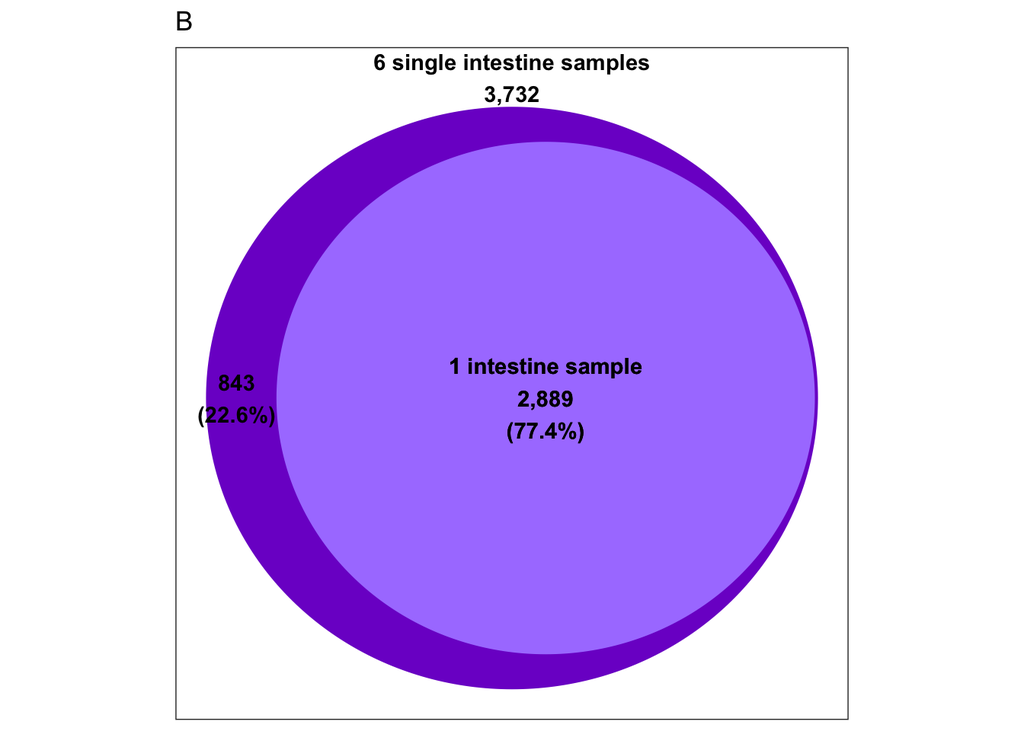

```r
# radius calculation for the smaller circle
data <- data.frame(x = c(0,0.11),
                   y = c(0,0),
                   r = c(1, 0.8797727),
                   fill = c("#7D26CD","#AB82FF"),
                   label = c("6 single intestine samples\n3,732", "1 intestine sample\n2,889\n(77.4%)"))

library(ggforce)
fig_B <-
  ggplot(data, aes(x0 = x, y0 = y, r = r)) +
  geom_circle(aes(fill = fill), color = NA) +
  scale_fill_identity() +
  geom_text(
    data = data[1,],
    aes(x = x, y = 1.1, label = label),
    fontface = "bold"
  ) +
  geom_text(
    data = data[2,],
    aes(x = x, y = y, label = label),
    fontface = "bold"
  ) +
  geom_text(
    data = data[2,],
    aes(x = x, y = y, label = label),
    fontface = "bold"
  ) +
  annotate("text",
           x = -0.9, y = 0,
           label = "843\n(22.6%)",
           fontface = "bold")+
  labs(title = "B") +
   theme_no_axes() +
  theme(aspect.ratio = 1)

fig_B
```

```r
ggsave("fig_B.png", fig_B, width = 5, height = 5)

#https://r-charts.com/colors/
#https://www.youtube.com/watch?v=saFyipc7Wd8
```

# Fig C

the gonad samples cluster together and intestine samples cluster together. However, the PCs based on the calculation here are different from the paper’s. I think the issue might be because of how the data was transformed. for example, they didn’t specify how exactly they processed missing data or zeros. so i couldn’t replicate their whole process exactly as them.

```r
CD_PCA_data <- fig_CD_data[,-c(1,2,4,5)]
CD_PCA_data <- CD_PCA_data[complete.cases(CD_PCA_data[,2:13]),]

sample_cols <- 2:13
CD_PCA_data_complete <- CD_PCA_data[complete.cases(CD_PCA_data[,sample_cols]), ]


matrix <- apply(CD_PCA_data_complete[, sample_cols], 2, function(x) as.numeric(as.character(x)))

matrix <- as.matrix(matrix)

rownames(matrix) <- CD_PCA_data_complete$`Gene name`

PCA <- prcomp(t(matrix), scale. = TRUE)

Tissue <- c("Gonad","Gonad","Gonad","Gonad","Gonad","Gonad","Intestine","Intestine","Intestine","Intestine","Intestine","Intestine" )


PCA_dataframe <-
  data.frame(
  sample = colnames(matrix),
  PC1 = PCA$x[,1],
  PC2 = PCA$x[,2],
  Tissue = Tissue
)

summary(PCA)
```

```
Importance of components:
                           PC1     PC2     PC3     PC4    PC5     PC6     PC7
Standard deviation     22.9727 13.9893 8.33864 5.59168 4.7949 4.48156 4.25832
Proportion of Variance  0.5693  0.2111 0.07501 0.03373 0.0248 0.02167 0.01956
Cumulative Proportion   0.5693  0.7804 0.85542 0.88915 0.9140 0.93562 0.95518
                           PC8     PC9    PC10    PC11      PC12
Standard deviation     3.42114 3.24481 3.19506 3.01737 1.206e-14
Proportion of Variance 0.01263 0.01136 0.01101 0.00982 0.000e+00
Cumulative Proportion  0.96781 0.97917 0.99018 1.00000 1.000e+00
```

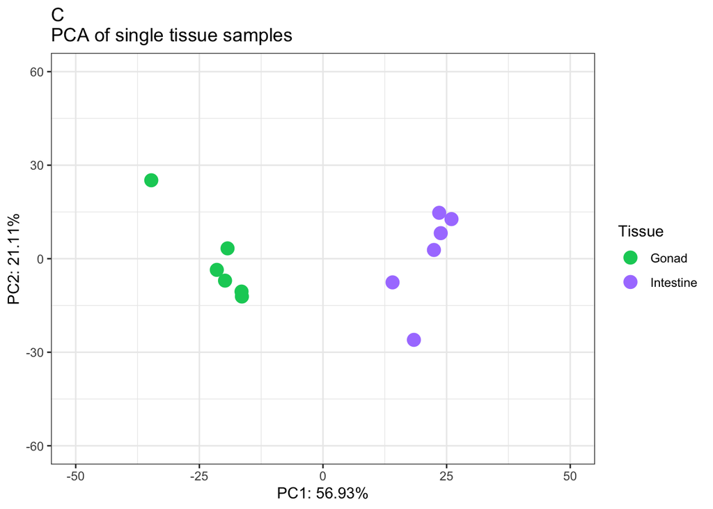

```r
fig_C <-
  ggplot(PCA_dataframe,
       aes(x = PC1, y = PC2,
           color = Tissue)) +
  geom_point(size = 4) +
  scale_color_manual(values = c("#00CD66","#AB82FF")) +
  xlim(-50, 50) +
  ylim(-60, 60) +
  labs(x = "PC1: 56.93%", y = "PC2: 21.11%", title = "C\nPCA of single tissue samples") +
  theme_bw()

fig_C
```

```r
ggsave("fig_C.png", fig_C, width = 7, height = 5)
```

```r
CD_PCA_data <- fig_CD_data[,-c(1,2,4,5)]
dataformin <- CD_PCA_data[,-1]
sample_cols <- 2:13

matrix <- apply(CD_PCA_data[, sample_cols], 2, function(x) as.numeric(as.character(x)))

min_value <- min(matrix_numeric, na.rm = TRUE)
```

```
Error: object 'matrix_numeric' not found
```

```r
matrix_numeric[is.na(matrix_numeric)] <- min_value * 0.01
```

```
Error: object 'min_value' not found
```

```r
matrix_numeric <- as.matrix(matrix_numeric)
```

```
Error: object 'matrix_numeric' not found
```

```r
rownames(matrix_numeric) <- CD_PCA_data$`Gene name`
```

```
Error: object 'matrix_numeric' not found
```

```r
matrix_transposed <- t(matrix_numeric)
```

```
Error: object 'matrix_numeric' not found
```

```r
#any(is.infinite(matrix_transposed))
matrix_transposed[is.infinite(matrix_transposed)] <- 0
```

```
Error: object 'matrix_transposed' not found
```

```r
PCA <- prcomp(t(matrix_transposed), scale. = TRUE)
```

```
Error: object 'matrix_transposed' not found
```

```r
summary(PCA)
```

```
Importance of components:
                           PC1     PC2     PC3     PC4    PC5     PC6     PC7
Standard deviation     22.9727 13.9893 8.33864 5.59168 4.7949 4.48156 4.25832
Proportion of Variance  0.5693  0.2111 0.07501 0.03373 0.0248 0.02167 0.01956
Cumulative Proportion   0.5693  0.7804 0.85542 0.88915 0.9140 0.93562 0.95518
                           PC8     PC9    PC10    PC11      PC12
Standard deviation     3.42114 3.24481 3.19506 3.01737 1.206e-14
Proportion of Variance 0.01263 0.01136 0.01101 0.00982 0.000e+00
Cumulative Proportion  0.96781 0.97917 0.99018 1.00000 1.000e+00
```

### Fig D

i tried to make the heat map with ggplot but then i found another package called pheatmap that made the tree at the top of the plot by default, which would be more conveinient than making the heat map and the tree separately and then combing the plots. So, for the final heat map, i used the pheatmap package.

[figure not shown]

```r
CD <- fig_CD_data[,-c(1,2,4,5)]
CD <- na.omit(CD)
CD[, 2:13] <- lapply(CD[, 2:13], as.numeric)

heatmap_data <-
  CD |>
  rowwise() |>
  mutate(across(-`Gene name`, ~(.-mean(c_across(-`Gene name`)))/sd(c_across(-`Gene name`)))) |>
  ungroup() |>
  pivot_longer(-`Gene name`,
               names_to = "sample",
               values_to = "Z_score")


heatmap_data <-
  heatmap_data |>
  mutate(tissue = str_extract(heatmap_data$sample,".{3}$")) |> group_by(tissue)

ggplot(heatmap_data,
       aes(x = sample, y = `Gene name`, fill = Z_score)) +
  geom_tile() +
  scale_fill_gradient2(low = "#0078ED", mid = "white", high = "red", midpoint = 0)
```

## heatmap calculation for pheatmap

```r
library(pheatmap)
library(tidyverse)

heatmap_data <-
  CD |>
  rowwise() |>
  mutate(across(-`Gene name`, ~(.-mean(c_across(-`Gene name`)))/sd(c_across(-`Gene name`)))) |>
  ungroup()

tissue <- str_sub(colnames(heatmap_data)[-1], -3, -3)
colnames(heatmap_data)[-1] <- tissue

mat <- as.matrix(heatmap_data[,-1])
rownames(mat) <- heatmap_data$`Gene name`
```

## plotting final heatmap

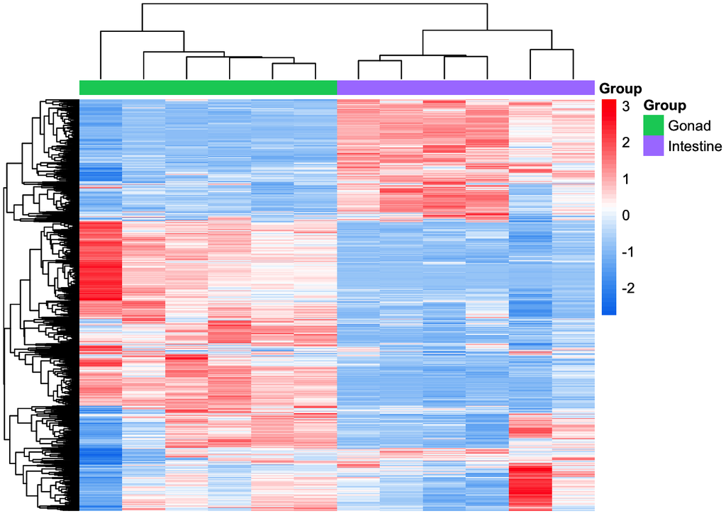

```r
colnames(mat) <- make.unique(colnames(mat))

sample_group <- c("Gonad","Gonad","Gonad","Gonad","Gonad","Gonad", "Intestine","Intestine","Intestine","Intestine","Intestine","Intestine")
annotation_col <- data.frame(
  Group = sample_group
)
rownames(annotation_col) <- colnames(mat)

annotation_colors <- list(
  Group = c(
    Gonad = "#00CD66",
    Intestine = "#AB82FF"
  )
)


#00CD66","#AB82FF

fig_D <-
  pheatmap(
  mat,
  color = colorRampPalette(c("#0078ED", "white", "red"))(50),
  annotation_col = annotation_col,
  annotation_colors = annotation_colors,
  show_rownames = FALSE,
  cluster_cols = TRUE,
  cluster_rows = TRUE,
  show_colnames = FALSE
)

fig_D
```

```r
ggsave("fig_D.png", fig_D, width = 5, height = 5)
```

### Fig E

```r
fig_E_data_gonad
```

```
# A tibble: 1,826 × 6
   `Shared in all samples` `Shared between five samples` Shared between four s…¹
   <chr>                   <chr>                         <chr>
 1 Y50D4B.4                ath-1                         pps-1
 2 prdx-2                  itsn-1                        Y105E8A.25
 3 M02H5.8                 rga-4                         F59E12.17
 4 ccar-1                  imb-2                         F22G12.5
 5 dhs-11                  vab-10                        pqn-80
 6 fipp-1                  ampd-1                        Y55F3BR.6
 7 spat-2                  twnk-1                        ubc-15
 8 unc-108                 C13B4.1                       acl-14
 9 rbm-26                  Y71F9AL.12                    tag-335
10 F53G2.12                mvk-1                         lsy-13
# ℹ 1,816 more rows
# ℹ abbreviated name: ¹`Shared between four samples`
# ℹ 3 more variables: `Shared between three samples` <chr>,
#   `Shared between two samples` <chr>, `Found in one sample only` <chr>
```

```r
#sum(!is.na(fig_E_data_gonad$`Shared in all samples`))

#sum(!is.na(fig_E_data_gonad$`Shared between five samples`))

#sum(!is.na(fig_E_data_gonad$`Shared between four samples`))

#sum(!is.na(fig_E_data_gonad$`Shared between three samples`))

#sum(!is.na(fig_E_data_gonad$`Shared between two samples`))

#sum(!is.na(fig_E_data_gonad$`Found in one sample only`))

gonad_data <- data.frame(sapply(fig_E_data_gonad, function(col) sum(!is.na(col))))
gonad_data$samples <- rownames(gonad_data)

intestine_data <- data.frame(sapply(fig_E_data_intestine, function(col) sum(!is.na(col))))
intestine_data$samples <- rownames(intestine_data)

fig_E_data <- left_join(gonad_data, intestine_data)
names(fig_E_data) <- c("gonad", "samples", "intestine")
fig_E_data$samples <- c("6", "5", "4", "3", "2", "1")

fig_E_data$gonad <- as.numeric(fig_E_data$gonad)
fig_E_data$intestine <- as.numeric(fig_E_data$intestine)
```

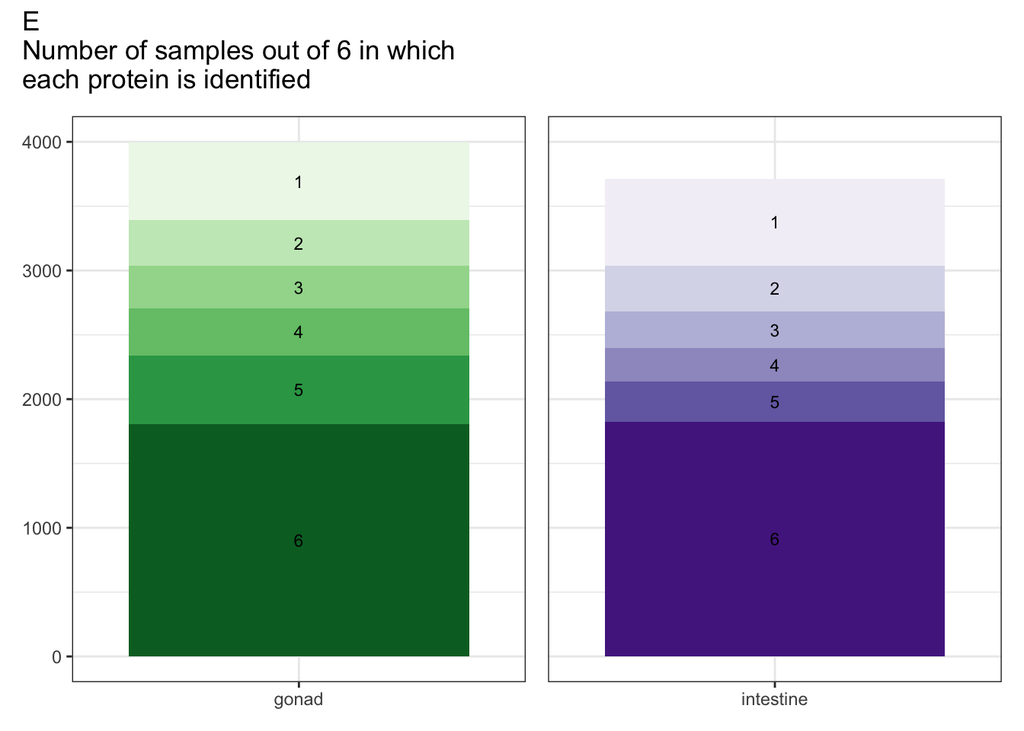

```r
fig_E_long <-
  fig_E_data |>
  pivot_longer(cols = c(gonad, intestine),
               names_to = "group", values_to = "sums")

gonad <-
  fig_E_long |>
  filter(group == "gonad") |>
ggplot(
       aes(x = group, y = sums, fill = samples)) +
  geom_bar(stat = "identity", show.legend = FALSE) +
  scale_fill_brewer(palette = "Greens") +
  geom_text(aes(label = samples),
            position = position_stack(vjust = 0.5),
            color = "black", size = 3) +
  ylim(0,4000)+
  xlab(NULL) +
  ylab(NULL) +
  theme(aspect.ratio = 2) +
  theme_bw()


intestine <-
  fig_E_long |>
  filter(group == "intestine") |>
ggplot(
       aes(x = group, y = sums, fill = samples)) +
  geom_bar(stat = "identity", show.legend = FALSE) +
  scale_fill_brewer(palette = "Purples") +
  geom_text(aes(label = samples),
            position = position_stack(vjust = 0.5),
            color = "black", size = 3) +
  ylim(0,4000)+
  xlab(NULL) +
  ylab(NULL) +
  theme(aspect.ratio = 2) +
  theme_bw()

# Remove y-axis from second plot
intestine_no_y <- intestine + theme(axis.title.y = element_blank(),
                       axis.text.y = element_blank(),
                       axis.ticks.y = element_blank())

# Combine side by side
final_E <- gonad + intestine_no_y + plot_annotation(title = "E\nNumber of samples out of 6 in which\neach protein is identified")

final_E
```

```r
ggsave("fig_E.png", plot = final_E, width = 5, height = 5)
```

### Fig F

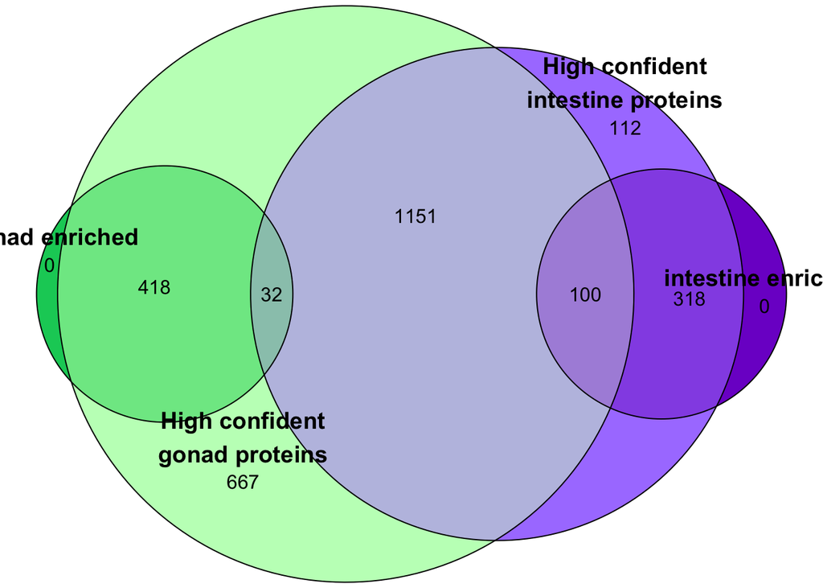

```r
fig_f <- fig_FG_data[,c(2, 4, 6, 12)]

names(fig_f) <- c("high_confident_gonad_enriched", "high_confident_intestine_enriched", "gonad_enriched", "intestine_enriched")

fig_f <- fig_f[-c(1,2),]

genes <- list(
  set1 = fig_f$high_confident_gonad_enriched,
  set2 = fig_f$high_confident_intestine_enriched,
  set3 = fig_f$gonad_enriched,
  set4 = fig_f$intestine_enriched
)

gene_sets <- lapply(genes, function(x) unique(na.omit(x)))
names(gene_sets) <- c("High confident\ngonad proteins",
                      "High confident\nintestine proteins",
                      "Gonad enriched", "intestine enriched")




euler_data <- euler(gene_sets, shape = "circle")

fig_F <-
  plot(
  euler_data,
  fills = c("#C1FFC1","#AB82FF" , "#00CD66", "#7D26CD"),
  edges = TRUE,
  quantities = TRUE,
  labels = list(font = 2, cex = 1.2),
)


fig_F
```

```r
ggsave("fig_F.png", plot = fig_F, width = 7, height = 5)
```

### Fig G

```r
fig_G_gonad <- fig_FG_data[-c(1,2), c(9,10,12)]
fig_G_intestine <- fig_FG_data[-c(1,2), c(12,15,16)]

fig_G_gonad$`Abundance Ratio (log2): (WT-Ix1) / (WT-Gx1)` <-
  as.numeric(fig_G_gonad$`Abundance Ratio (log2): (WT-Ix1) / (WT-Gx1)`)
fig_G_gonad$`Abundance Ratio P-Value: (WT-Ix1) / (WT-Gx1)` <-
  as.numeric(fig_G_gonad$`Abundance Ratio P-Value: (WT-Ix1) / (WT-Gx1)`)
fig_G_gonad$tissue <- "gonad"




fig_G_intestine$`Abundance Ratio (log2): (WT-Ix1) / (WT-Gx1)` <-
  as.numeric(fig_G_intestine$`Abundance Ratio (log2): (WT-Ix1) / (WT-Gx1)`)
fig_G_intestine$`Abundance Ratio P-Value: (WT-Ix1) / (WT-Gx1)` <-
  as.numeric(fig_G_intestine$`Abundance Ratio P-Value: (WT-Ix1) / (WT-Gx1)`)
fig_G_intestine$tissue <- "intestine"




fig_G_gonad <- fig_G_gonad |>
  filter(!is.na(`Abundance Ratio (log2): (WT-Ix1) / (WT-Gx1)`) &
           !is.na(`Abundance Ratio P-Value: (WT-Ix1) / (WT-Gx1)`)) |>
  mutate(log10p = -log10(`Abundance Ratio P-Value: (WT-Ix1) / (WT-Gx1)`))
fig_G_intestine <- fig_G_intestine |>
  filter(!is.na(`Abundance Ratio (log2): (WT-Ix1) / (WT-Gx1)`) &
           !is.na(`Abundance Ratio P-Value: (WT-Ix1) / (WT-Gx1)`)) |>
  mutate(log10p = -log10(`Abundance Ratio P-Value: (WT-Ix1) / (WT-Gx1)`))





combined_data <- bind_rows(fig_G_gonad, fig_G_intestine)
```

### Some of the data for the volcano plot is missing. Only the genes that are above the 0.05 pvalue are there in the dataset. I tried labeling the genes using cutoff but couldn’t find one that would label all the genes that they have labeled. I tried to manually label the genes that they labeled, some of them are still not showing up.

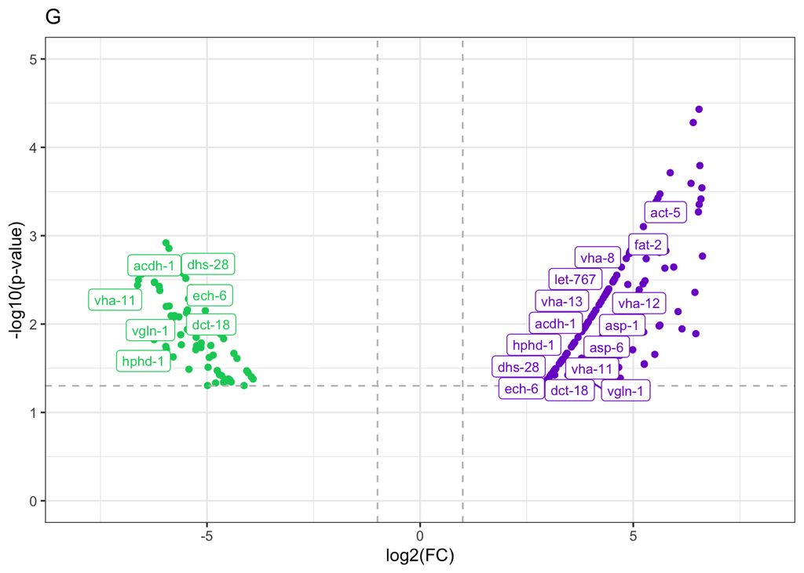

```r
gene_to_label <- c("prp-8", "let-716", "fln-1", "glh-1", "nmy-2", "cey-2", "snrp-200", "cey-3", "npp-12", "ngp-1", "cgh-1", "asb-1", "car-1, his-40", "ech-6", "vha-11", "hphd-1", "dct-18", "vgln-1", "dhs-28", "acdh-1", "act-5", "vha-8", "asp-6", "vha-13", "fat-2", "asp-1", "let-767", "vha-12", "lro-1")

label_data <- combined_data[combined_data$`Gene name` %in% gene_to_label, ]



fig_G <-
  ggplot(combined_data,
       aes(x = `Abundance Ratio (log2): (WT-Ix1) / (WT-Gx1)`,
           y = log10p,
           color = tissue)) +
  geom_point(size = 1.5, na.rm = TRUE) +
  scale_color_manual(values =
                       c("gonad"="#00CD66", "intestine"="#7D26CD"), guide = "none") +
  ylim(0, 5) +
  xlim(-8,8) +
  labs(y = "-log10(p-value)", x = "log2(FC)") +
  geom_vline(xintercept = c(-1, 1),
             linetype = "dashed",
             color = "grey") +
  geom_hline(yintercept = -log10(0.05),
             linetype = "dashed",
             color = "grey") +
  geom_label_repel(data = label_data,
                  aes(label = `Gene name`),
                  size = 3,
                  box.padding = unit(0.01, "lines"),
                  point.padding = unit(3, "lines"),
                  max.overlaps = Inf,
                  ) +
  labs(title = "G") +
  theme(aspect.ratio = 1) +
  theme_bw()



  ggsave("fig_G.png", plot = fig_G, width = 7, height = 5)
  fig_G
```

```r
combined_data
```

```
# A tibble: 868 × 5
   Abundance Ratio (log2): (W…¹ Abundance Ratio P-Va…² `Gene name` tissue log10p
                          <dbl>                  <dbl> <chr>       <chr>   <dbl>
 1                        -6.64                  1e-17 ifb-2       gonad      17
 2                        -6.64                  1e-17 nep-17      gonad      17
 3                        -6.64                  1e-17 T25C12.3    gonad      17
 4                        -6.64                  1e-17 ctsa-2      gonad      17
 5                        -6.64                  1e-17 ifc-2       gonad      17
 6                        -6.64                  1e-17 irg-8       gonad      17
 7                        -6.64                  1e-17 hpo-34      gonad      17
 8                        -6.64                  1e-17 F28B4.3     gonad      17
 9                        -6.64                  1e-17 C18B2.5     gonad      17
10                        -6.64                  1e-17 vha-6       gonad      17
# ℹ 858 more rows
# ℹ abbreviated names: ¹`Abundance Ratio (log2): (WT-Ix1) / (WT-Gx1)`,
#   ²`Abundance Ratio P-Value: (WT-Ix1) / (WT-Gx1)`
```

```r
combined_data |>
  filter(`Abundance Ratio (log2): (WT-Ix1) / (WT-Gx1)` > 6) |> arrange()
```

```
# A tibble: 288 × 5
   Abundance Ratio (log2): (W…¹ Abundance Ratio P-Va…² `Gene name` tissue log10p
                          <dbl>                  <dbl> <chr>       <chr>   <dbl>
 1                         6.64                  1e-17 ifb-2       intes…     17
 2                         6.64                  1e-17 nep-17      intes…     17
 3                         6.64                  1e-17 T25C12.3    intes…     17
 4                         6.64                  1e-17 ctsa-2      intes…     17
 5                         6.64                  1e-17 ifc-2       intes…     17
 6                         6.64                  1e-17 irg-8       intes…     17
 7                         6.64                  1e-17 hpo-34      intes…     17
 8                         6.64                  1e-17 F28B4.3     intes…     17
 9                         6.64                  1e-17 C18B2.5     intes…     17
10                         6.64                  1e-17 vha-6       intes…     17
# ℹ 278 more rows
# ℹ abbreviated names: ¹`Abundance Ratio (log2): (WT-Ix1) / (WT-Gx1)`,
#   ²`Abundance Ratio P-Value: (WT-Ix1) / (WT-Gx1)`
```

```r
combined_data |>
  filter(`Abundance Ratio (log2): (WT-Ix1) / (WT-Gx1)` < -6) |> count()
```

```
# A tibble: 1 × 1
      n
  <int>
1   394
```

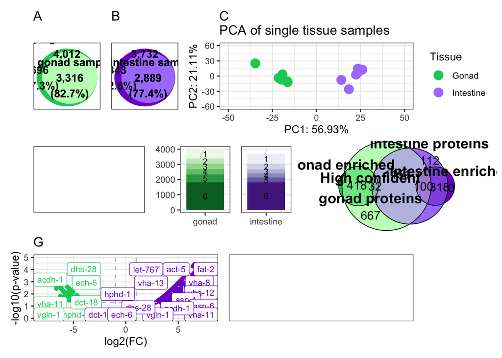

```r
blank_fig <- ggplot() +theme_bw()

final_plot <- (fig_A + fig_B + fig_C) / (blank_fig + final_E + fig_F) / (fig_G + blank_fig)

final_plot
```

```r
ggsave("final_plot.png", plot = final_plot, width = 10, height = 10)
```

Resources used:

A video by datadraft showed how to make circles in ggplot. i used the bases of that to make fig A and B https://www.youtube.com/watch?v=saFyipc7Wd8

i used the following website to get the hexadecimal numbers: https://r-charts.com/colors/

I used “[ggplot heatmap legend doesn’t represent negative numbers](https://stackoverflow.com/questions/7536639/ggplot-heatmap-legend-doesnt-represent-negative-numbers)” on stack overflow to help with the ggmap heatmap.

pheatmap https://davetang.org/muse/2018/05/15/making-a-heatmap-in-r-with-the-pheatmap-package/

geom label repel https://ggrepel.slowkow.com/reference/geom_text_repel

AI, especially the google searches that provides option to get AI output, was used for trouble shooting. It was mostly used for labeling in the volcano plot and using the pheatmap package.